# Home Lab, part 0: The “Why”?

homelab

selfhosting

linux

Author

Kyle Grealis

Published

April 22, 2025

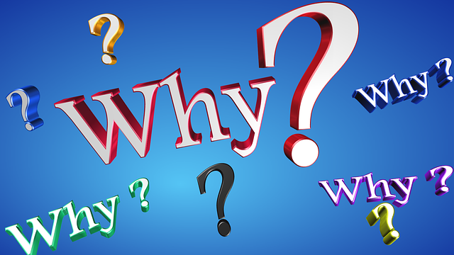

> This is multipart series where I elaborate on the details of configuring my homelab. I’ve installed Ubuntu 25.04 (“Plucky Puffin”) as the operating system on my Lenovo laptop and am running Debian 12 (“bookworm”) on my main 8GB Raspberry Pi 5. The Pi is the host device for the other services listed throughout this series.

Steps not covered:

- Installing Linux on your machine
- Initial configuration a Raspberry Pi
- Basics of SSH to remotely access devices on your home network

## Purpose of my Home Lab

The origin of this project is hopefully relatable to you, the reader: I just wanted to see if I could just do it. This question though was: am I capable of deploying self-hosted services on my home network, and then safely & securely access them from outside the home?

Networking? Never heard of her, well not insofar as an academic data analyst. Our team tends to operate more in GitHub collaborative projects (thus my potential over-posting of GitHub things here, here and especially here). I just wanted to geek out, `rsync` my [Timeshift](https://teejee2008.github.io/timeshift/) backups and other files off my laptop to another device, and feel like one of the cool tech kids.

**ImportantUPDATE:**

I’m still not a cool kid, but got this working so there you go!

The main goals I established before undertaking this project were:

- Learn to remotely access devices on my home network
- Share files across devices
- Set-up a Raspberry Pi for self-hosted services
- Learn “WTH is Docker and how do I use it?”
- **Make it so that only *I* can access these on a secure connection!** No connection, no access.
- Test how much I can de-Google & de-Apple my life

The last part involved needing to find ways to self-host document & file management and photos. The cost of using cloud storage isn’t all that intrusive, but it does add up over time. One major hurdle would be leaving the comfort of known apps and have it all fitting easily into daily life.

Happily, with help from [`r/selfhosted`](https://www.reddit.com/r/selfhosted/) and some feedback from YouTube, I’ve been able to tweak things just enough to make it work for me. I should have stated this towards the top, but I’ve made plenty of mistakes and had a few moments of “oh $h!t… did I just brick my system, lose my data, erase *x, y, & z*??” but…

Live, laugh, and backup all your important things first!

Share your insights at kylegrealis@proton.me. Together, we can make our R projects more robust, reproducible, and ready for collaboration!

Happy coding!

~Kyle